# Coursework Report

*N* removed NAs: 2

*N* removed typo: 1

*N* removed <18: 26

*N* total clean: 121

| Group | *N* | *M*<sub>age</sub> | *M*<sub>rating</sub> |
| --- | --- | --- | --- |
| Control | 62 | 20.8 | 6.74 |
| Experim | 59 | 20.9 | 5.69 |

**Main analysis results**

*t*(119) = 6.46, *p* < .001

[interactive chart not shown]

[figure not shown]

[interactive chart not shown]

# Coursework Report

Analysing Data, Spring 2020

# Methods

## Participants

This was a study on how the colour red affects females’ perception of a male’s attractiveness. The study was performed on women only. There were 150 participants originally. A total of 26 were removed because they were too young (under 18) and 0 were removed for being too old (over 99). A total of 3 were removed due to errors when giving their age or not giving their age. The sample had a (*M* <sub>age</sub> = 20.85, *SD*<sub>age</sub> = 2.13, range = 9). Table 1 shows the number and age of participants in each condition.

*Table 1* Summary of Participant Demographics by Experimental Condition

| *Condition* | *Count* | *M<sub>age</sub>* | *SD<sub>age</sub>* | *Min<sub>age</sub>* | *Max<sub>age</sub>* |
| --- | --- | --- | --- | --- | --- |
| control | 62 | 20.8 | 2.21 | 18 | 27 |
| experimental | 59 | 20.9 | 2.06 | 18 | 27 |

## Design

The hypothesis was that the colour of the background will influence how women rate the attractiveness of a man’s photograph. The independent variable, which is a factor variable, is the background colour, either red or white, of a black and white photo of a male. The red coloured background was the experimental group and the control group viewed the white background. The dependent variable is the level of attraction the women felt towards the male, which is a range variable. To measure how attractive the male was, each woman was asked how attractive they thought he is, how pleasant he looked and how attractive would he be in real life. These were scored on a 9-point scale with 1 being not at all attractive and 9 meaning extremely attractive. His overall attractiveness was a composite score of the mean of the three measures. The conceptual hypothesis is that colour has an influence on how one perceives the attractiveness of another. The operational hypothesis is that the colour red will increase the attractiveness rating that is assigned to a black and white photo of a male. A *t*-test statistical analysis will be used to test this hypothesis. A t-test analysis compares the mean of two conditions.

# Results

Table 2 shows the score demographics. Figure 1 shows a comparison of the average rating of each condition.

*Table 2* Summary of mean ratings by condition

| Condition | Item 1 *M* | Item 1 *SD* | Item 2 *M* | Item 2 *SD* | Item 3 *M* | Item 3 *SD* |
| --- | --- | --- | --- | --- | --- | --- |
| control | 6.65 | 1.46 | 6.74 | 1.44 | 6.84 | 1.28 |
| experimental | 5.66 | 1.59 | 5.53 | 1.29 | 5.88 | 1.39 |

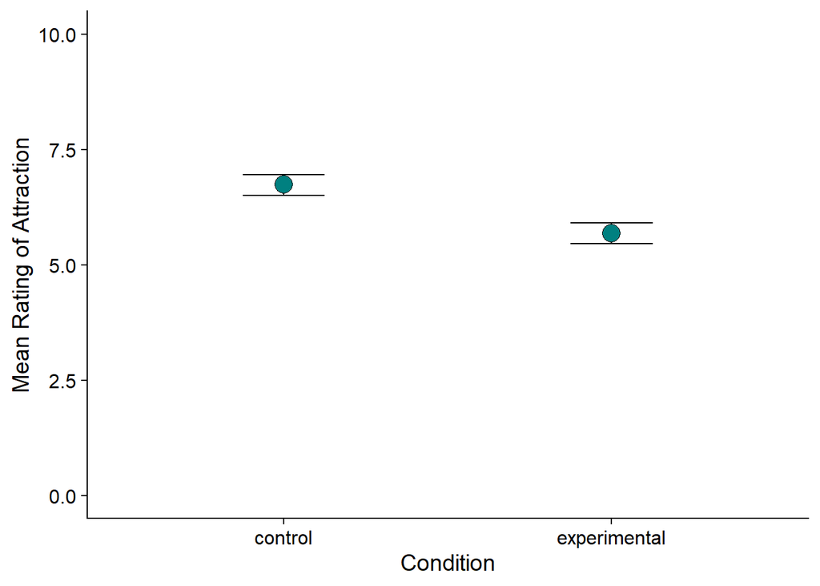

Figure 1: plot of the average score for each condition

# Discussion

My results, however, contradict other examples of research. When replicating the effect of the colour red, Peperkoorn et al (2016) demonstrated that women dressed in red were not seen as being more attractive to both Dutch and American males compared to women in black or white tops. If the red effect was universal, then samples from different cultures would rate the women in the red condition as more attractive. As this was not observed in the study it may imply that the red effect may not be universal. A limitation of the research undertaken was the low number of participants. A total of 121 participant’s scores were analysed. As a result of this small sample, the size of the effect may not be accurate. Future studies into this effect should attempt to sample from multiple societies to examine whether the effect is universal. This will also allow for a greater sample to analyse for effect size. With the results contrasting to studies with greater sample totals, such as Peperkoorn et al’s (2016) four hundred and thirty participants, it implies that the colour effect may be less robust than previously thought.

My results suggesting a colour effect also contrasts with Francis’ (2013) report on the bias of publication in Elliot et al’s (2010) experiments investigating the red effect. Other replications reported that red was not predicted to have an influence on men’s ratings of attractiveness of another male (Francis, 2013). Analysis of studies that had accepted the null hypothesis, that red does not have an effect on perceived attractiveness, suggested that the effect’s size was less than what Elliot et al reported (Francis, 2013). If the results are hard to replicate it may suggest that the theory Elliot et al presents is not valid. Future research into this effect may want to access the thought process behind the person’s decision when rating photograph by asking them to explain why.

One limitation of my study was the lack of ecological validity due to the photograph being presented as black and white photograph and the colour provided by the background. In a natural environment, men are observed in colour as well as typically in front of different coloured backgrounds or multi-coloured backgrounds as opposed to a block of red or white. As a result of this method, we could only access how the background colour affects perception of attractiveness and so cannot comment on whether other areas of colour may influence scores. Other areas might include a person’s facial colouring, such as cheek redness or lip colour. In previous studies, photographs of men that have been altered to increase redness were judged as significantly more attractive (Stephen et al., 2012). As a result of this lack of ecological validity, the effect may be less applicable in a technological world where photographs rarely not in colour. Replications of this experiment should present colour photographs and have four conditions instead, white-background, white-background-with-red-cheeks, red-background and red-background-with-red-cheeks to examine if face colouration is a distinct influence or if it modulates the red effect.

Another weakness of the study was that the study did not take into account the man’s hair or fashion style. Hair colour has a significant influence on scores of attraction towards females (Swami et al., 2008). It is important to note that sample in Swami et al’s (2008) experiment were male and female judging a photograph of a female unlike the only female sample in my experiment. Therefore, the results found in Swami et al’s (2008) experiment might have a gender effect which is not seen in my results. Perceptions of cute are influenced by “wearing sporty, non formal clothes” (Ashmore et al., 1996, p1095). Perceptions of sexiness are affected by how “unclothed” the model is (Ashmore et al., 1996, p1095). In my study, because only three questions were asked with nothing about the participant’s preference on male fashion or hair colour and style. Knowing if these visual aspects of the photograph may have influenced the scores cannot be accessed. If this study were to be repeated, then the model’s hair and fashion should also be made variables to better understand the context that the red effect is and is not observed in.

Alternative explanations for significant results should be investigated. Personal preference is a variable that was not controlled in the experiment. Women prefer taller men with more masculine facial features (Elliot et al., 2010). This variable of personal preference may have a great influence on how participants rate the model’s attractiveness. If the model has facial characteristics or hair colour that the participants prefer, they may be scored higher in attractiveness because of this influence. To understand whether the red effect is the only factor influencing the perceived attractiveness, future participants should be presented with models of different races, with different hair styles and wearing different fashion styles. Other physical traits such as height, weight and facial deformities should also be variables. This will allow for comments on whether the red effect is the sole reason for differences in attractiveness in the red and white condition.

In conclusion, in my results a red background had a significant influence on how attractive a male is rated by a woman. Replications of this method have observed mixed results, with red sometimes having a significant influence on the scores of attractiveness. As a result, more studies should be initiated to understand how the red effect interacts with other variables that conventionally have an influence on how attractive someone is.

# References

Ashmore, R. D., Solomon, M. R., & Longo, L. C. (1996). Thinking about Fashion Models’

Looks: A Multidimensional Approach to the Structure of Perceived Physical Attractiveness. *Personality and Social Psychology Bulletin, 22*(11), 1083–1104. https://doi.org/10.1177/01461672962211001

Elliot, A. J., Niesta Kayser, D., Greitemeyer, T., Lichtenfeld, S., Gramzow, R. H.,

Maier, M. A., & Liu, H. (2010). Red, rank, and romance in women viewing men. *Journal of Experimental Psychology: General, 139*(3), 399–417. https://doi.org/10.1037/a0019689

Francis, G. (2013). Publication bias in “Red, rank, and romance in women viewing men,” by

Elliot et al. (2010). *Journal of Experimental Psychology: General, 142*(1), 292–296. http://dx.doi.org/10.1037/a0027923

Hesslinger, V. M., Goldbach, L., & Carbon, C.-C. (2015). Men in red: A reexamination of

the red-attractiveness effect. *Psychonomic Bulletin & Review, 22*(4), 1142–1148. https://doi.org/10.3758/s13423-015-0866-8

Peperkoorn, L. S., Roberts, S. C., & Pollet, T. V. (2016). Revisiting the Red Effect on

Attractiveness and Sexual Receptivity: No Effect of the Color Red on Human Mate Preferences. *Evolutionary Psychology, 14*(4), 1474704916673841. https://doi.org/10.1177/1474704916673841

Schwarz, S., & Singer, M. (2013). Romantic red revisited: Red enhances men’s attraction

to young, but not menopausal women. *Journal of Experimental Social Psychology, 49*(1), 161–164. https://doi.org/10.1016/j.jesp.2012.08.004

Stephen, I. D., Oldham, F. H., Perrett, D. I., & Barton, R. A. (2012). Redness Enhances

Perceived Aggression, Dominance